# The Wildchild: Latent Variable and Exploratory Models for Differentiating Purpose and Happiness

Authors

Affiliations

Todd B. Kashdan

George Mason University

Patrick E. McKnight

George Mason University

James C. Kaufman

University of Connecticut

Abstract

This companion analysis takes an empirically-driven, exploratory approach to the same research question addressed in our theory-driven manuscript – whether purpose in life and subjective happiness differentially predict striving-related, daily goal, coping, and growth outcomes. Here, we build measurement models from the item level using confirmatory and exploratory factor analysis, test a bifactor model to establish discriminant validity at the latent level, fit structural equation models comparing latent purpose and happiness paths to latent outcomes, and explore the data through network analysis and latent profile analysis. The goal is to see whether the story told by observed-variable correlations holds when we move to latent constructs that correct for measurement error and allow more complex structural relationships. Where the two approaches converge, confidence in the findings increases. Where they diverge, the discrepancy is informative.

Keywords

purpose in life, subjective happiness, structural equation modeling, latent variable models, network analysis, bifactor models, measurement models

# Preamble: Why a Wildchild Version?

This document is the empirically-driven companion to our theory-driven Purpose3 manuscript. The original version uses observed composite scores (POMP-transformed means), multiple imputation, and MI-pooled partial correlations with Williams’ t-tests. That approach is transparent, interpretable, and directly tied to our hypotheses.

This version asks: **what happens when we let the data speak more freely?** We use:

1. **Measurement models** (CFA) to establish that purpose and happiness are well-measured and truly distinct constructs at the latent level
2. **Structural equation models** (SEM) to compare latent purpose vs. latent happiness paths to latent outcomes — correcting for measurement error
3. **Bifactor models** to decompose shared vs. unique variance between purpose and happiness
4. **Network analysis** to visualize the system of relationships without imposing directionality
5. **Latent profile analysis** to identify subgroups defined by purpose-happiness combinations

The guiding question remains the same: **Does purpose predict resilience, growth, and regulatory flexibility more strongly than happiness?** But we test it with different tools and fewer theoretical constraints.

# Setup

**Show R code**

```r
# ── Core packages ──
# Load psych FIRST to avoid select() masking dplyr
library(psych)
library(tidyverse)
library(lavaan)
library(semTools)    # for compRelSEM, reliability
library(knitr)
library(kableExtra)

# Resolve namespace conflicts
select <- dplyr::select

# ── Load data ──
dat <- read.csv(gzfile("alldatPvH4LLM.csv.gz"))
cat("Total N:", nrow(dat), "\n")
```

```
Total N: 345
```

**Show R code**

```r
cat("Total variables:", ncol(dat), "\n")
```

```
Total variables: 3557
```

# Part 1: Measurement Models

Before testing any structural relationships, we must establish that our constructs are well-measured. This section fits CFAs for each key measure, reports fit indices and reliability, and flags any problems.

## 1.1 Happiness: Subjective Happiness Scale (SHS)

**Show R code**

```r
# SHS items (0-6 scale): general happiness, relative happiness, characterization x2
# Item 4 is reverse-scored; use the _r version
shs_items <- c("b_shs_gh_a", "b_shs_rh_a", "b_shs_ch_a", "b_shs_ch_b_r")

# Check which items exist and have variance
shs_available <- shs_items[shs_items %in% names(dat)]
cat("SHS items found:", length(shs_available), "\n")
```

```
SHS items found: 4
```

**Show R code**

```r
cat("Items:", paste(shs_available, collapse = ", "), "\n")
```

```
Items: b_shs_gh_a, b_shs_rh_a, b_shs_ch_a, b_shs_ch_b_r
```

**Show R code**

```r
# Quick descriptives
shs_data <- dat[, shs_available]
cat("\nSHS Item descriptives:\n")
```

```
SHS Item descriptives:
```

**Show R code**

```r
print(describe(shs_data)[, c("n", "mean", "sd", "min", "max", "skew", "kurtosis")])
```

```
               n mean   sd min max  skew kurtosis
b_shs_gh_a   328 4.03 1.30   0   6 -0.57     0.19
b_shs_rh_a   328 3.61 1.54   0   6 -0.27    -0.66
b_shs_ch_a   328 3.49 1.64   0   6 -0.38    -0.63
b_shs_ch_b_r 328 3.73 1.80   0   6 -0.27    -1.19
```

**Show R code**

```r
# CFA: single factor
shs_model <- '
  happiness =~ b_shs_gh_a + b_shs_rh_a + b_shs_ch_a + b_shs_ch_b_r
'

shs_fit <- cfa(shs_model, data = dat, missing = "fiml", estimator = "MLR")
cat("\n── SHS CFA Fit ──\n")
```

```
── SHS CFA Fit ──
```

**Show R code**

```r
summary(shs_fit, fit.measures = TRUE, standardized = TRUE)
```

```
lavaan 0.6-21 ended normally after 22 iterations

  Estimator                                         ML
  Optimization method                           NLMINB
  Number of model parameters                        12

                                                  Used       Total
  Number of observations                           328         345
  Number of missing patterns                         1

Model Test User Model:
                                              Standard      Scaled
  Test Statistic                                 5.980       5.278
  Degrees of freedom                                 2           2
  P-value (Chi-square)                           0.050       0.071
  Scaling correction factor                                  1.133
    Yuan-Bentler correction (Mplus variant)

Model Test Baseline Model:

  Test statistic                               781.850     553.752
  Degrees of freedom                                 6           6
  P-value                                        0.000       0.000
  Scaling correction factor                                  1.412

User Model versus Baseline Model:

  Comparative Fit Index (CFI)                    0.995       0.994
  Tucker-Lewis Index (TLI)                       0.985       0.982

  Robust Comparative Fit Index (CFI)                         0.995
  Robust Tucker-Lewis Index (TLI)                            0.985

Loglikelihood and Information Criteria:

  Loglikelihood user model (H0)              -2054.074   -2054.074
  Scaling correction factor                                  1.091
      for the MLR correction
  Loglikelihood unrestricted model (H1)      -2051.084   -2051.084
  Scaling correction factor                                  1.097
```

[output cut: 37 more lines]

```

Intercepts:
                   Estimate  Std.Err  z-value  P(>|z|)   Std.lv  Std.all
   .b_shs_gh_a        4.034    0.072   56.381    0.000    4.034    3.113
   .b_shs_rh_a        3.607    0.085   42.570    0.000    3.607    2.351
   .b_shs_ch_a        3.494    0.091   38.588    0.000    3.494    2.131
   .b_shs_ch_b_r      3.732    0.099   37.553    0.000    3.732    2.073

Variances:
                   Estimate  Std.Err  z-value  P(>|z|)   Std.lv  Std.all
   .b_shs_gh_a        0.333    0.043    7.690    0.000    0.333    0.198
   .b_shs_rh_a        0.460    0.071    6.454    0.000    0.460    0.196
   .b_shs_ch_a        0.951    0.128    7.452    0.000    0.951    0.354
   .b_shs_ch_b_r      1.895    0.187   10.127    0.000    1.895    0.585
    happiness         1.346    0.136    9.928    0.000    1.000    1.000
```

**Show R code**

```r
# Extract key fit indices
shs_fitmeasures <- fitMeasures(shs_fit, c("chisq.scaled", "df", "pvalue.scaled",
                                            "cfi.robust", "tli.robust",
                                            "rmsea.robust", "srmr"))
cat("\nKey fit indices:\n")
```

```
Key fit indices:
```

**Show R code**

```r
print(round(shs_fitmeasures, 3))
```

```
 chisq.scaled            df pvalue.scaled    cfi.robust    tli.robust
        5.278         2.000         0.071         0.995         0.985
 rmsea.robust          srmr
        0.076         0.014
```

**Show R code**

```r
# Reliability: omega from lavaan
shs_rel <- compRelSEM(shs_fit)
cat("\nComposite reliability (omega):", round(shs_rel, 3), "\n")
```

```
Composite reliability (omega): 0.87
```

## 1.2 Purpose: Brief Purpose in Life (BPURP)

Also 4 items, so similar identification constraints as SHS.

**Show R code**

```r
bpurp_items <- c("b_bpurp_1", "b_bpurp_2", "b_bpurp_3", "b_bpurp_4")
bpurp_available <- bpurp_items[bpurp_items %in% names(dat)]
cat("BPURP items found:", length(bpurp_available), "\n")
```

```
BPURP items found: 4
```

**Show R code**

```r
bpurp_data <- dat[, bpurp_available]
cat("\nBPURP Item descriptives:\n")
```

```
BPURP Item descriptives:
```

**Show R code**

```r
print(describe(bpurp_data)[, c("n", "mean", "sd", "min", "max", "skew", "kurtosis")])
```

```
            n mean   sd min max  skew kurtosis
b_bpurp_1 314 2.90 1.07   0   4 -0.95     0.28
b_bpurp_2 314 2.98 0.97   0   4 -0.93     0.56
b_bpurp_3 314 2.49 1.16   0   4 -0.59    -0.48
b_bpurp_4 314 2.46 1.11   0   4 -0.43    -0.62
```

**Show R code**

```r
bpurp_model <- '
  purpose =~ b_bpurp_1 + b_bpurp_2 + b_bpurp_3 + b_bpurp_4
'

bpurp_fit <- cfa(bpurp_model, data = dat, missing = "fiml", estimator = "MLR")
cat("\n── BPURP CFA Fit ──\n")
```

```
── BPURP CFA Fit ──
```

**Show R code**

```r
summary(bpurp_fit, fit.measures = TRUE, standardized = TRUE)
```

```
lavaan 0.6-21 ended normally after 16 iterations

  Estimator                                         ML
  Optimization method                           NLMINB
  Number of model parameters                        12

                                                  Used       Total
  Number of observations                           314         345
  Number of missing patterns                         1

Model Test User Model:
                                              Standard      Scaled
  Test Statistic                                18.266      12.564
  Degrees of freedom                                 2           2
  P-value (Chi-square)                           0.000       0.002
  Scaling correction factor                                  1.454
    Yuan-Bentler correction (Mplus variant)

Model Test Baseline Model:

  Test statistic                               561.462     349.572
  Degrees of freedom                                 6           6
  P-value                                        0.000       0.000
  Scaling correction factor                                  1.606

User Model versus Baseline Model:

  Comparative Fit Index (CFI)                    0.971       0.969
  Tucker-Lewis Index (TLI)                       0.912       0.908

  Robust Comparative Fit Index (CFI)                         0.972
  Robust Tucker-Lewis Index (TLI)                            0.916

Loglikelihood and Information Criteria:

  Loglikelihood user model (H0)              -1601.824   -1601.824
  Scaling correction factor                                  1.220
      for the MLR correction
  Loglikelihood unrestricted model (H1)      -1592.691   -1592.691
  Scaling correction factor                                  1.253
```

[output cut: 37 more lines]

```

Intercepts:
                   Estimate  Std.Err  z-value  P(>|z|)   Std.lv  Std.all
   .b_bpurp_1         2.904    0.060   48.259    0.000    2.904    2.723
   .b_bpurp_2         2.978    0.055   54.268    0.000    2.978    3.063
   .b_bpurp_3         2.487    0.065   37.998    0.000    2.487    2.144
   .b_bpurp_4         2.465    0.063   39.288    0.000    2.465    2.217

Variances:
                   Estimate  Std.Err  z-value  P(>|z|)   Std.lv  Std.all
   .b_bpurp_1         0.331    0.053    6.267    0.000    0.331    0.291
   .b_bpurp_2         0.523    0.072    7.243    0.000    0.523    0.553
   .b_bpurp_3         0.344    0.065    5.266    0.000    0.344    0.256
   .b_bpurp_4         0.664    0.079    8.363    0.000    0.664    0.538
    purpose           0.807    0.104    7.781    0.000    1.000    1.000
```

**Show R code**

```r
bpurp_fitmeasures <- fitMeasures(bpurp_fit, c("chisq.scaled", "df", "pvalue.scaled",
                                                "cfi.robust", "tli.robust",
                                                "rmsea.robust", "srmr"))
cat("\nKey fit indices:\n")
```

```
Key fit indices:
```

**Show R code**

```r
print(round(bpurp_fitmeasures, 3))
```

```
 chisq.scaled            df pvalue.scaled    cfi.robust    tli.robust
       12.564         2.000         0.002         0.972         0.916
 rmsea.robust          srmr
        0.157         0.030
```

**Show R code**

```r
bpurp_rel <- compRelSEM(bpurp_fit)
cat("\nComposite reliability (omega):", round(bpurp_rel, 3), "\n")
```

```
Composite reliability (omega): 0.859
```

## 1.3 Discriminant Validity: Joint Purpose-Happiness CFA

The critical test: are purpose and happiness distinct latent constructs? We fit a 2-factor model (purpose, happiness) and compare it to a 1-factor model. If the 2-factor model fits significantly better and the latent correlation is well below 1.0, we have discriminant validity.

**Show R code**

```r
# Two-factor model
joint_2f_model <- '
  purpose   =~ b_bpurp_1 + b_bpurp_2 + b_bpurp_3 + b_bpurp_4
  happiness =~ b_shs_gh_a + b_shs_rh_a + b_shs_ch_a + b_shs_ch_b_r
'

joint_2f_fit <- cfa(joint_2f_model, data = dat, missing = "fiml", estimator = "MLR")

# One-factor model (purpose and happiness are the same thing)
joint_1f_model <- '
  general =~ b_bpurp_1 + b_bpurp_2 + b_bpurp_3 + b_bpurp_4 +
             b_shs_gh_a + b_shs_rh_a + b_shs_ch_a + b_shs_ch_b_r
'

joint_1f_fit <- cfa(joint_1f_model, data = dat, missing = "fiml", estimator = "MLR")

cat("── Model Comparison: 1-Factor vs 2-Factor ──\n")
```

```
── Model Comparison: 1-Factor vs 2-Factor ──
```

**Show R code**

```r
comp <- anova(joint_1f_fit, joint_2f_fit)
print(comp)
```

```
Scaled Chi-Squared Difference Test (method = "satorra.bentler.2001")

lavaan->lavTestLRT():
   lavaan NOTE: The "Chisq" column contains standard test statistics, not the
   robust test that should be reported per model. A robust difference test is
   a function of two standard (not robust) statistics.

             Df    AIC    BIC   Chisq Chisq diff Df diff Pr(>Chisq)
joint_2f_fit 19 7309.7 7404.5  41.823
joint_1f_fit 20 7729.6 7820.7 463.780     251.15       1  < 2.2e-16 ***
---
Signif. codes:  0 '***' 0.001 '**' 0.01 '*' 0.05 '.' 0.1 ' ' 1
```

**Show R code**

```r
cat("\n── 2-Factor Fit ──\n")
```

```
── 2-Factor Fit ──
```

**Show R code**

```r
joint_2f_fm <- fitMeasures(joint_2f_fit, c("chisq.scaled", "df", "pvalue.scaled",
                                             "cfi.robust", "tli.robust",
                                             "rmsea.robust", "srmr"))
print(round(joint_2f_fm, 3))
```

```
 chisq.scaled            df pvalue.scaled    cfi.robust    tli.robust
       35.663        19.000         0.012         0.986         0.979
 rmsea.robust          srmr
        0.057         0.028
```

**Show R code**

```r
cat("\n── 1-Factor Fit ──\n")
```

```
── 1-Factor Fit ──
```

**Show R code**

```r
joint_1f_fm <- fitMeasures(joint_1f_fit, c("chisq.scaled", "df", "pvalue.scaled",
                                             "cfi.robust", "tli.robust",
                                             "rmsea.robust", "srmr"))
print(round(joint_1f_fm, 3))
```

```
 chisq.scaled            df pvalue.scaled    cfi.robust    tli.robust
      387.097        20.000         0.000         0.673         0.543
 rmsea.robust          srmr
        0.265         0.157
```

**Show R code**

```r
# Latent correlation between purpose and happiness
cat("\n── Latent Correlation (purpose ↔ happiness) ──\n")
```

```
── Latent Correlation (purpose ↔ happiness) ──
```

**Show R code**

```r
latent_cor <- lavInspect(joint_2f_fit, "cor.lv")
print(round(latent_cor, 3))
```

```
          purpos hppnss
purpose    1.000
happiness  0.439  1.000
```

**Show R code**

```r
cat("\nFor reference, observed r =", round(cor(dat$b_bpurp_mean_POMP, dat$b_shs_mean_POMP, use = "complete.obs"), 3), "\n")
```

```
For reference, observed r = 0.396
```

**Show R code**

```r
cat("Latent r is expected to be HIGHER because it corrects for attenuation due to measurement error.\n")
```

```
Latent r is expected to be HIGHER because it corrects for attenuation due to measurement error.
```

## 1.4 Bifactor Model: General Positivity + Specific Factors

This is where things get interesting. A bifactor model posits:

- A **general factor** (G) that loads on ALL 8 items (shared variance between purpose and happiness — call it “general positivity”)
- A **purpose-specific factor** (S-P) that loads only on the 4 BPURP items (what’s unique to purpose after removing general positivity)
- A **happiness-specific factor** (S-H) that loads only on the 4 SHS items (what’s unique to happiness)

If the specific factors have meaningful loadings, then purpose and happiness each carry unique variance beyond their overlap. This is a stronger test of discriminant validity than factor correlation alone.

**Show R code**

```r
bifactor_model <- '
  # General factor loads on all items
  G  =~ b_bpurp_1 + b_bpurp_2 + b_bpurp_3 + b_bpurp_4 +
        b_shs_gh_a + b_shs_rh_a + b_shs_ch_a + b_shs_ch_b_r

  # Purpose-specific factor (orthogonal to G)
  SP =~ b_bpurp_1 + b_bpurp_2 + b_bpurp_3 + b_bpurp_4

  # Happiness-specific factor (orthogonal to G)
  SH =~ b_shs_gh_a + b_shs_rh_a + b_shs_ch_a + b_shs_ch_b_r
'

# Bifactor models require orthogonal factors
bifactor_fit <- tryCatch(
  cfa(bifactor_model, data = dat, missing = "fiml", estimator = "MLR",
      orthogonal = TRUE),
  error = function(e) {
    cat("Bifactor model did not converge. This is common with only 4 items per group.\n")
    cat("Error:", e$message, "\n")
    NULL
  }
)

# Check convergence before accessing fit measures
bf_converged <- !is.null(bifactor_fit) && lavInspect(bifactor_fit, "converged")

if (bf_converged) {
  cat("── Bifactor Model Fit ──\n")
  bf_fm <- fitMeasures(bifactor_fit, c("chisq.scaled", "df", "pvalue.scaled",
                                        "cfi.robust", "tli.robust",
                                        "rmsea.robust", "srmr"))
  print(round(bf_fm, 3))

  cat("\n── Standardized Loadings ──\n")
  bf_std <- standardizedSolution(bifactor_fit)
  bf_loadings <- bf_std[bf_std$op == "=~", c("lhs", "rhs", "est.std", "pvalue")]
  names(bf_loadings) <- c("Factor", "Item", "Std.Loading", "p")
  print(bf_loadings, digits = 3)

  # Explained Common Variance (ECV): proportion of variance due to general factor
  general_loadings <- bf_loadings$Std.Loading[bf_loadings$Factor == "G"]
  specific_loadings <- bf_loadings$Std.Loading[bf_loadings$Factor != "G"]
  ECV <- sum(general_loadings^2) / (sum(general_loadings^2) + sum(specific_loadings^2))
  cat("\nExplained Common Variance (ECV) for General factor:", round(ECV, 3), "\n")
  cat("ECV > .70 suggests a strong general factor; ECV < .50 means specific factors dominate.\n")
  cat("Interpretation: If ECV is low, purpose and happiness have substantial UNIQUE variance.\n")
} else {
  cat("\n── Bifactor model did NOT converge ──\n")
  cat("This is expected with only 4 items per specific factor (8 items total).\n")
  cat("Bifactor models typically need 5+ indicators per group factor for stable estimation.\n")
  cat("\nFalling back to the correlated 2-factor model for discriminant validity.\n")
  cat("The 2-factor latent r already provides strong evidence for construct distinctness.\n")
  if (exists("latent_cor")) {
    cat(sprintf("Latent r(purpose, happiness) = %.3f\n", latent_cor[1,2]))
    cat("This is substantially below 1.0, supporting discriminant validity.\n")
  }
}
```

```
── Bifactor model did NOT converge ──
This is expected with only 4 items per specific factor (8 items total).
Bifactor models typically need 5+ indicators per group factor for stable estimation.

Falling back to the correlated 2-factor model for discriminant validity.
The 2-factor latent r already provides strong evidence for construct distinctness.
Latent r(purpose, happiness) = 0.439
This is substantially below 1.0, supporting discriminant validity.
```

## 1.5 Measurement Models for Key Outcomes

We need latent outcomes for the SEM. Let’s build measurement models for the scales with sufficient items.

**Show R code**

```r
# ── Function to fit CFA and report results ──
fit_report_cfa <- function(model_syntax, data, label) {
  fit <- tryCatch(
    cfa(model_syntax, data = data, missing = "fiml", estimator = "MLR"),
    error = function(e) { cat(label, "- ERROR:", e$message, "\n"); return(NULL) }
  )
  if (is.null(fit)) return(NULL)

  fm <- fitMeasures(fit, c("chisq.scaled", "df", "pvalue.scaled",
                            "cfi.robust", "tli.robust",
                            "rmsea.robust", "srmr"))
  rel <- tryCatch(compRelSEM(fit), error = function(e) NA)

  cat(sprintf("\n── %s ──\n", label))
  cat(sprintf("  CFI = %.3f, TLI = %.3f, RMSEA = %.3f, SRMR = %.3f, omega = %.3f\n",
              fm["cfi.robust"], fm["tli.robust"], fm["rmsea.robust"], fm["srmr"], rel))

  return(list(fit = fit, measures = fm, omega = rel))
}

# ── SWLS (5 items, 0-6 scale) ──
swls_cfa <- fit_report_cfa(
  'swls =~ b_swls_1 + b_swls_2 + b_swls_3 + b_swls_4 + b_swls_5',
  dat, "Satisfaction with Life (SWLS)")
```

```
── Satisfaction with Life (SWLS) ──
  CFI = 0.987, TLI = 0.975, RMSEA = 0.077, SRMR = 0.025, omega = 0.863
```

**Show R code**

```r
# ── GSHS (7 items: 1 general + 3 pathways + 3 agency, 0-8 scale) ──
# Two-factor: pathways + agency
gshs_cfa <- fit_report_cfa(
  'pathways =~ b_gshs_path_1 + b_gshs_path_3 + b_gshs_path_4
   agency   =~ b_gshs_agen_2 + b_gshs_agen_5 + b_gshs_agen_6',
  dat, "Goal-Specific Hope (GSHS) - 2 factor")
```

```
── Goal-Specific Hope (GSHS) - 2 factor ──
  CFI = 0.994, TLI = 0.989, RMSEA = 0.048, SRMR = 0.022, omega = 0.846
   CFI = 0.994, TLI = 0.989, RMSEA = 0.048, SRMR = 0.022, omega = 0.801
```

**Show R code**

```r
# ── PHQ-8 (8 items, 0-3 scale) ──
phq_cfa <- fit_report_cfa(
  'depression =~ b_phq_1 + b_phq_2 + b_phq_3 + b_phq_4 + b_phq_5 + b_phq_6 + b_phq_7 + b_phq_8',
  dat, "Depression (PHQ-8)")
```

```
── Depression (PHQ-8) ──
  CFI = 0.896, TLI = 0.855, RMSEA = 0.117, SRMR = 0.055, omega = 0.834
```

**Show R code**

```r
# ── ICSA (21 items: 10 cognitive + 11 somatic) ──
icsa_cfa <- fit_report_cfa(
  'cognitive =~ b_icsa_c_3 + b_icsa_c_4 + b_icsa_c_5 + b_icsa_c_9 + b_icsa_c_10 +
                b_icsa_c_11 + b_icsa_c_13 + b_icsa_c_16 + b_icsa_c_17 + b_icsa_c_19
   somatic  =~ b_icsa_s_1 + b_icsa_s_2 + b_icsa_s_6 + b_icsa_s_7 + b_icsa_s_8 +
                b_icsa_s_12 + b_icsa_s_14 + b_icsa_s_15 + b_icsa_s_18 + b_icsa_s_20 + b_icsa_s_21',
  dat, "Anxiety (ICSA) - 2 factor")
```

```
── Anxiety (ICSA) - 2 factor ──
  CFI = 0.891, TLI = 0.879, RMSEA = 0.066, SRMR = 0.054, omega = 0.882
   CFI = 0.891, TLI = 0.879, RMSEA = 0.066, SRMR = 0.054, omega = 0.844
```

**Show R code**

```r
# ── BMPNS: 3 needs, satisfaction items only (3 items each) ──
bmpns_cfa <- fit_report_cfa(
  'autonomy    =~ b_bmpns_as_3 + b_bmpns_as_9 + b_bmpns_as_15
   competence  =~ b_bmpns_cs_2 + b_bmpns_cs_8 + b_bmpns_cs_14
   relatedness =~ b_bmpns_rs_1 + b_bmpns_rs_7 + b_bmpns_rs_13',
  dat, "Basic Needs (BMPNS) - 3 factor (satisfaction)")
```

```
── Basic Needs (BMPNS) - 3 factor (satisfaction) ──
  CFI = 0.977, TLI = 0.965, RMSEA = 0.060, SRMR = 0.032, omega = 0.654
   CFI = 0.977, TLI = 0.965, RMSEA = 0.060, SRMR = 0.032, omega = 0.848
   CFI = 0.977, TLI = 0.965, RMSEA = 0.060, SRMR = 0.032, omega = 0.837
```

**Show R code**

```r
# ── Collect fit summary ──
fit_summary <- tibble(
  Scale = c("SHS", "BPURP", "Joint 2-Factor", "SWLS", "GSHS", "PHQ-8", "ICSA", "BMPNS"),
  Items = c(4, 4, 8, 5, 6, 8, 21, 9),
  CFI = c(shs_fitmeasures["cfi.robust"], bpurp_fitmeasures["cfi.robust"],
          joint_2f_fm["cfi.robust"],
          ifelse(!is.null(swls_cfa), swls_cfa$measures["cfi.robust"], NA),
          ifelse(!is.null(gshs_cfa), gshs_cfa$measures["cfi.robust"], NA),
          ifelse(!is.null(phq_cfa), phq_cfa$measures["cfi.robust"], NA),
          ifelse(!is.null(icsa_cfa), icsa_cfa$measures["cfi.robust"], NA),
          ifelse(!is.null(bmpns_cfa), bmpns_cfa$measures["cfi.robust"], NA)),
  RMSEA = c(shs_fitmeasures["rmsea.robust"], bpurp_fitmeasures["rmsea.robust"],
            joint_2f_fm["rmsea.robust"],
            ifelse(!is.null(swls_cfa), swls_cfa$measures["rmsea.robust"], NA),
            ifelse(!is.null(gshs_cfa), gshs_cfa$measures["rmsea.robust"], NA),
            ifelse(!is.null(phq_cfa), phq_cfa$measures["rmsea.robust"], NA),
            ifelse(!is.null(icsa_cfa), icsa_cfa$measures["rmsea.robust"], NA),
            ifelse(!is.null(bmpns_cfa), bmpns_cfa$measures["rmsea.robust"], NA)),
  Omega = c(shs_rel, bpurp_rel, NA,
            ifelse(!is.null(swls_cfa), swls_cfa$omega, NA),
            ifelse(!is.null(gshs_cfa), gshs_cfa$omega, NA),
            ifelse(!is.null(phq_cfa), phq_cfa$omega, NA),
            ifelse(!is.null(icsa_cfa), icsa_cfa$omega, NA),
            ifelse(!is.null(bmpns_cfa), bmpns_cfa$omega, NA))
)

cat("\n\n── Measurement Model Summary ──\n")
```

```
── Measurement Model Summary ──
```

**Show R code**

```r
kable(fit_summary, digits = 3, caption = "CFA Fit Indices Across Scales") %>%
  kable_styling(bootstrap_options = c("striped", "hover"), full_width = FALSE)
```

CFA Fit Indices Across Scales

| Scale | Items | CFI | RMSEA | Omega |
| --- | --- | --- | --- | --- |
| SHS | 4 | 0.995 | 0.076 | 0.870 |
| BPURP | 4 | 0.972 | 0.157 | 0.859 |
| Joint 2-Factor | 8 | 0.986 | 0.057 | NA |
| SWLS | 5 | 0.987 | 0.077 | 0.863 |
| GSHS | 6 | 0.994 | 0.048 | 0.846 |
| PHQ-8 | 8 | 0.896 | 0.117 | 0.834 |
| ICSA | 21 | 0.891 | 0.066 | 0.882 |
| BMPNS | 9 | 0.977 | 0.060 | 0.654 |

# Part 2: Structural Equation Models

Now the main event: latent purpose and latent happiness as simultaneous predictors of latent outcomes. This is the SEM analog of partial correlations — each IV’s path to the DV is estimated while controlling for the other IV.

## 2.1 SEM: Latent Purpose & Happiness → Well-Being Outcomes

We fit a series of models where latent purpose and latent happiness simultaneously predict each latent outcome. The key comparison: are the standardized paths from purpose vs. happiness significantly different?

**Show R code**

```r
# ── Function to fit SEM with two latent IVs predicting one latent DV ──
fit_sem_comparison <- function(dv_model, dv_label, data) {

  full_model <- paste0('
    # Measurement models for IVs
    purpose   =~ b_bpurp_1 + b_bpurp_2 + b_bpurp_3 + b_bpurp_4
    happiness =~ b_shs_gh_a + b_shs_rh_a + b_shs_ch_a + b_shs_ch_b_r

    # Measurement model for DV
    ', dv_model, '

    # Structural paths
    ', dv_label, ' ~ b_p*purpose + b_h*happiness

    # Test: are paths equal?
    diff := b_p - b_h
  ')

  fit <- tryCatch(
    sem(full_model, data = data, missing = "fiml", estimator = "MLR"),
    error = function(e) { cat("SEM for", dv_label, "failed:", e$message, "\n"); NULL }
  )

  if (is.null(fit)) return(NULL)

  # Extract key results
  params <- parameterEstimates(fit, standardized = TRUE)
  paths <- params[params$label %in% c("b_p", "b_h", "diff"), ]

  fm <- fitMeasures(fit, c("cfi.robust", "tli.robust", "rmsea.robust", "srmr"))

  list(
    fit = fit,
    paths = paths,
    fitMeasures = fm,
    dv = dv_label,
    beta_purpose = paths$std.all[paths$label == "b_p"],
    beta_happiness = paths$std.all[paths$label == "b_h"],
    diff_est = paths$est[paths$label == "diff"],
    diff_p = paths$pvalue[paths$label == "diff"]
  )
}

# ── Fit SEMs for each outcome ──
sem_results <- list()

# 1. Life Satisfaction (SWLS)
sem_results$swls <- fit_sem_comparison(
  'swls =~ b_swls_1 + b_swls_2 + b_swls_3 + b_swls_4 + b_swls_5',
  'swls', dat)

# 2. Hope - Pathways
sem_results$hope_path <- fit_sem_comparison(
  'hope_path =~ b_gshs_path_1 + b_gshs_path_3 + b_gshs_path_4',
  'hope_path', dat)

# 3. Hope - Agency
sem_results$hope_agen <- fit_sem_comparison(
  'hope_agen =~ b_gshs_agen_2 + b_gshs_agen_5 + b_gshs_agen_6',
  'hope_agen', dat)

# 4. Depression (PHQ-8)
sem_results$depression <- fit_sem_comparison(
  'depression =~ b_phq_1 + b_phq_2 + b_phq_3 + b_phq_4 + b_phq_5 + b_phq_6 + b_phq_7 + b_phq_8',
  'depression', dat)

# 5. Cognitive Anxiety
sem_results$anx_cog <- fit_sem_comparison(
  'anx_cog =~ b_icsa_c_3 + b_icsa_c_4 + b_icsa_c_5 + b_icsa_c_9 + b_icsa_c_10 +
              b_icsa_c_11 + b_icsa_c_13 + b_icsa_c_16 + b_icsa_c_17 + b_icsa_c_19',
  'anx_cog', dat)

# 6. Somatic Anxiety
sem_results$anx_som <- fit_sem_comparison(
  'anx_som =~ b_icsa_s_1 + b_icsa_s_2 + b_icsa_s_6 + b_icsa_s_7 + b_icsa_s_8 +
              b_icsa_s_12 + b_icsa_s_14 + b_icsa_s_15 + b_icsa_s_18 + b_icsa_s_20 + b_icsa_s_21',
  'anx_som', dat)

# 7. Autonomy
sem_results$autonomy <- fit_sem_comparison(
  'autonomy =~ b_bmpns_as_3 + b_bmpns_as_9 + b_bmpns_as_15',
  'autonomy', dat)

# 8. Competence
sem_results$competence <- fit_sem_comparison(
  'competence =~ b_bmpns_cs_2 + b_bmpns_cs_8 + b_bmpns_cs_14',
  'competence', dat)

# 9. Relatedness
sem_results$relatedness <- fit_sem_comparison(
  'relatedness =~ b_bmpns_rs_1 + b_bmpns_rs_7 + b_bmpns_rs_13',
  'relatedness', dat)

# ── Compile results table ──
sem_table <- bind_rows(lapply(sem_results, function(r) {
  if (is.null(r)) return(NULL)
  tibble(
    Outcome = r$dv,
    `β Purpose` = r$beta_purpose,
    `β Happiness` = r$beta_happiness,
    `Diff (P - H)` = r$diff_est,
    `p (diff)` = r$diff_p,
    CFI = r$fitMeasures["cfi.robust"],
    RMSEA = r$fitMeasures["rmsea.robust"]
  )
}))

# FDR correction
if (nrow(sem_table) > 0) {
  sem_table$`p (FDR)` <- p.adjust(sem_table$`p (diff)`, method = "BH")
  sem_table$Sig <- ifelse(sem_table$`p (FDR)` < .05, "*", "")

  # ── Valence coding ──
  # Depression and anxiety are negatively valenced (higher = worse), and BOTH
  # constructs load negatively on them. A raw mean of betas, or the raw sign of
  # (b_p - b_h), then treats the *less protective* construct as "stronger." We
  # flip the sign on these outcomes so that throughout, higher = better and a
  # positive valenced diff means purpose is the stronger *beneficial* path.
  neg_latent <- c("depression", "anx_cog", "anx_som")
  flip <- ifelse(sem_table$Outcome %in% neg_latent, -1, 1)
  sem_table$`βv Purpose`   <- sem_table$`β Purpose`   * flip
  sem_table$`βv Happiness` <- sem_table$`β Happiness` * flip
  sem_table$`Valenced diff (P-H)` <- sem_table$`βv Purpose` - sem_table$`βv Happiness`

  cat("\n── SEM Path Comparison: Latent Purpose vs Latent Happiness ──\n")
  kable(sem_table %>% dplyr::select(Outcome, `β Purpose`, `β Happiness`,
          `Valenced diff (P-H)`, `p (diff)`, `p (FDR)`, Sig, CFI, RMSEA),
        digits = 3,
        caption = "Standardized SEM paths from latent purpose and latent happiness. Valenced diff sign-corrects the negatively-valenced outcomes (depression, anxiety) so that positive = purpose the stronger beneficial path.") %>%
    kable_styling(bootstrap_options = c("striped", "hover"), full_width = FALSE) %>%
    footnote(general = "* p < .05 (BH FDR-corrected), testing equality of the two paths. Valenced diff > 0 = purpose the stronger beneficial predictor; depression and anxiety are sign-flipped (higher = better mental health). FIML with MLR.")
}
```

```
── SEM Path Comparison: Latent Purpose vs Latent Happiness ──
```

Standardized SEM paths from latent purpose and latent happiness. Valenced diff sign-corrects the negatively-valenced outcomes (depression, anxiety) so that positive = purpose the stronger beneficial path.

Outcome

β Purpose

β Happiness

Valenced diff (P-H)

p (diff)

p (FDR)

Sig

CFI

RMSEA

swls

0.327

0.515

-0.189

0.372

0.418

0.977

0.052

hope_path

0.315

0.293

0.022

0.478

0.478

0.991

0.036

hope_agen

0.424

0.325

0.099

0.172

0.259

0.989

0.039

depression

-0.097

-0.560

-0.463

0.003

0.012

0.942

0.065

anx_cog

-0.092

-0.586

-0.494

0.002

0.012

0.960

0.051

anx_som

-0.034

-0.346

-0.312

0.045

0.122

0.939

0.055

autonomy

0.436

0.380

0.056

0.257

0.331

0.987

0.040

competence

0.371

0.277

0.094

0.173

0.259

0.983

0.049

relatedness

0.144

0.461

-0.316

0.054

0.122

0.986

0.044

Note:

* p < .05 (BH FDR-corrected), testing equality of the two paths. Valenced diff > 0 = purpose the stronger beneficial predictor; depression and anxiety are sign-flipped (higher = better mental health). FIML with MLR.

Standardized SEM Paths: Latent Purpose vs. Latent Happiness Predicting Well-Being

**Show R code**

```
# ── Summary statistics (valence-corrected) ──
# These pooled numbers are a rough summary, not a verdict: the nine outcomes are
# conceptually distinct and differently valenced (autonomy vs. depression), so a
# single averaged path is not interpretable on its own. Read the per-outcome
# paths above. The pattern there is context-specific, not a clean win for either
# construct: purpose paths are larger for agentic outcomes (hope, autonomy,
# competence), happiness paths for affective and distress outcomes (life
# satisfaction, relatedness, depression, anxiety).
if (nrow(sem_table) > 0) {
  cat("\n── Summary (valence-corrected; read per-outcome, not as a verdict) ──\n")
  cat("Average valenced β for purpose:", round(mean(sem_table$`βv Purpose`, na.rm = TRUE), 3), "\n")
  cat("Average valenced β for happiness:", round(mean(sem_table$`βv Happiness`, na.rm = TRUE), 3), "\n")
  n_purpose_stronger <- sum(sem_table$`Valenced diff (P-H)` > 0, na.rm = TRUE)
  cat("Purpose the stronger beneficial path in", n_purpose_stronger, "of", nrow(sem_table), "outcomes\n")
  n_sig_diff <- sum(sem_table$`p (FDR)` < .05, na.rm = TRUE)
  cat("Significant path differences (FDR < .05):", n_sig_diff, "of", nrow(sem_table),
      "(these favor whichever construct has the larger beneficial path)\n")
}
```

```
── Summary (valence-corrected; read per-outcome, not as a verdict) ──
Average valenced β for purpose: 0.249
Average valenced β for happiness: 0.416
Purpose the stronger beneficial path in 4 of 9 outcomes
Significant path differences (FDR < .05): 2 of 9 (these favor whichever construct has the larger beneficial path)
```

2.2 SEM with Observed DV Composites (Strivings & DRM)

For outcomes without item-level data in the dataset (strivings, DRM goal items), we use a hybrid approach: latent IVs predicting observed DVs. This still corrects for measurement error in the predictors.

**Show R code**

```
# ── POMP utility ──
pomp <- function(x, min_possible, max_possible) {
  (x - min_possible) / (max_possible - min_possible) * 100
}

# Create POMP-transformed striving harmony
dat$TOT_STRIVIMPACT_POMP <- pomp(dat$TOT_STRIVIMPACT, -2, 2)

# DRM goal averages (already created in setup of original manuscript)
drm_goal_labels <- c("Difficulty", "Competence", "Effort", "Distress",
                      "Joy", "Meaning", "Control", "Values_consistency",
                      "Progress", "Autonomy")
for (i in 1:10) {
  ep_cols <- paste0("Striv_", i, "_POMP_E", 1:5)
  available <- ep_cols[ep_cols %in% names(dat)]
  if (length(available) > 0) {
    dat[[paste0("DRM_goal_", drm_goal_labels[i])]] <-
      rowMeans(dat[, available, drop = FALSE], na.rm = TRUE)
  }
}

# DRM affect
pa_cols <- paste0("Avg_PA_DRM_POMP_E", 1:5)
na_cols <- paste0("Avg_NA_DRM_POMP_E", 1:5)
dat$DRM_PA_avg <- rowMeans(dat[, pa_cols[pa_cols %in% names(dat)], drop = FALSE], na.rm = TRUE)
dat$DRM_NA_avg <- rowMeans(dat[, na_cols[na_cols %in% names(dat)], drop = FALSE], na.rm = TRUE)

# ── Function: Latent IVs → Observed DV ──
fit_sem_obs_dv <- function(dv_name, data) {
  model <- paste0('
    # Latent IVs
    purpose   =~ b_bpurp_1 + b_bpurp_2 + b_bpurp_3 + b_bpurp_4
    happiness =~ b_shs_gh_a + b_shs_rh_a + b_shs_ch_a + b_shs_ch_b_r

    # Structural: latent IVs → observed DV
    ', dv_name, ' ~ b_p*purpose + b_h*happiness

    # Test equality
    diff := b_p - b_h
  ')
```

[output cut: 55 more lines]

```
  # Distress, daily negative affect, and difficulty are negatively valenced.
  neg_obs <- c("Distress", "DRM_NA", "Difficulty")
  flip_obs <- ifelse(obs_sem_table$Outcome %in% neg_obs, -1, 1)
  obs_sem_table$`βv Purpose`   <- obs_sem_table$`β Purpose`   * flip_obs
  obs_sem_table$`βv Happiness` <- obs_sem_table$`β Happiness` * flip_obs
  obs_sem_table$`Valenced diff (P-H)` <- obs_sem_table$`βv Purpose` - obs_sem_table$`βv Happiness`

  cat("\n── SEM: Latent IVs → Observed DVs (Strivings + DRM) ──\n")
  kable(obs_sem_table %>% dplyr::select(Outcome, `β Purpose`, `β Happiness`,
          `Valenced diff (P-H)`, `p (diff)`, `p (FDR)`, Sig),
        digits = 3,
        caption = "Latent purpose and happiness predicting observed striving and DRM composites. Valenced diff sign-corrects distress, negative affect, and difficulty so positive = purpose stronger beneficial path.") %>%
    kable_styling(bootstrap_options = c("striped", "hover"), full_width = FALSE) %>%
    footnote(general = "* p < .05 (BH FDR-corrected), testing equality of paths. Valenced diff > 0 = purpose the stronger beneficial predictor (distress/NA/difficulty sign-flipped). FIML with MLR; latent IVs correct for measurement error in predictors.")
}
```

```
── SEM: Latent IVs → Observed DVs (Strivings + DRM) ──
```

Latent purpose and happiness predicting observed striving and DRM composites. Valenced diff sign-corrects distress, negative affect, and difficulty so positive = purpose stronger beneficial path.

| Outcome | β Purpose | β Happiness | Valenced diff (P-H) | p (diff) | p (FDR) | Sig |
| --- | --- | --- | --- | --- | --- | --- |
| CENTRALITY | 0.218 | 0.054 | 0.164 | 0.152 | 0.541 |  |
| SELFORG | 0.218 | 0.189 | 0.029 | 0.518 | 0.834 |  |
| LIFEAIM | 0.148 | -0.022 | 0.169 | 0.146 | 0.541 |  |
| PURPOSE_Pursuit | 0.221 | 0.062 | 0.159 | 0.186 | 0.541 |  |
| EFFORT | 0.160 | 0.121 | 0.040 | 0.584 | 0.834 |  |
| SUCCESS | 0.159 | 0.192 | -0.032 | 0.935 | 0.979 |  |
| STRIVPURSUIT | 0.256 | 0.152 | 0.104 | 0.238 | 0.596 |  |
| STRIVIMPACT | -0.004 | -0.024 | 0.020 | 0.905 | 0.979 |  |
| Difficulty | -0.021 | -0.111 | -0.090 | 0.554 | 0.834 |  |
| Competence | 0.150 | 0.253 | -0.103 | 0.670 | 0.893 |  |
| Effort | 0.140 | 0.037 | 0.103 | 0.305 | 0.677 |  |
| Distress | -0.112 | -0.178 | -0.066 | 0.816 | 0.979 |  |
| Joy | 0.041 | 0.349 | -0.309 | 0.019 | 0.188 |  |
| Meaning | 0.097 | 0.290 | -0.193 | 0.189 | 0.541 |  |
| Control | 0.150 | 0.183 | -0.033 | 0.938 | 0.979 |  |
| Values_consistency | 0.097 | 0.236 | -0.139 | 0.400 | 0.727 |  |
| Progress | 0.146 | 0.192 | -0.046 | 0.979 | 0.979 |  |
| Autonomy | 0.134 | 0.043 | 0.091 | 0.353 | 0.705 |  |
| DRM_PA | 0.071 | 0.417 | -0.345 | 0.008 | 0.164 |  |
| DRM_NA | 0.007 | -0.298 | -0.305 | 0.049 | 0.329 |  |

Note:  
* p < .05 (BH FDR-corrected), testing equality of paths. Valenced diff > 0 = purpose the stronger beneficial predictor (distress/NA/difficulty sign-flipped). FIML with MLR; latent IVs correct for measurement error in predictors.

SEM Paths: Latent Purpose and Happiness Predicting Observed Striving and DRM Outcomes

Reading the SEM results

Two cautions before interpreting these paths. First, the outcomes are differently valenced: depression, anxiety, distress, and daily negative affect are scored so that higher is worse, and both constructs load negatively on them. We sign-correct these outcomes (“valenced diff”) so that a positive difference always means purpose is the stronger *beneficial* predictor; without that correction, a construct that is more protective against depression would be miscounted as the weaker one. Second, we do not read the pooled “purpose stronger in X of Y” counts as a verdict. Averaging a path to autonomy against a path to depression is not meaningful, so the per-outcome table is primary.

Read that way, the latent models tell the same context-specific story as the observed-variable manuscript rather than a different one. The two constructs have nearly identical reliability (omega around .87 for both), so disattenuation has little to correct and the latent paths track the observed partials closely. Purpose has the larger path to agentic outcomes – hope, autonomy, competence, and the striving composites; happiness has the larger path to affective and distress outcomes – life satisfaction, relatedness, depression, anxiety, and daily positive affect. Among the 20 observed striving and DRM outcomes, no path difference survives FDR correction. The disattenuated evidence converges with the observed-variable evidence: neither construct is uniformly the stronger predictor.

2.3 Comparison Figure: SEM Path Coefficients

**Show R code**

```
# Combine all SEM results
all_results <- bind_rows(
  if (exists("sem_table") && nrow(sem_table) > 0)
    sem_table %>% dplyr::select(Outcome, `β Purpose`, `β Happiness`) %>%
      mutate(Domain = "Latent DVs") else NULL,
  if (exists("obs_sem_table") && nrow(obs_sem_table) > 0)
    obs_sem_table %>% dplyr::select(Outcome, `β Purpose`, `β Happiness`) %>%
      mutate(Domain = ifelse(grepl("CENTRAL|SELF|LIFE|PURPOSE|EFFORT|SUCCESS|STRIV", Outcome),
                             "Strivings", "DRM Goals")) else NULL
)

if (nrow(all_results) > 0) {
  plot_data <- all_results %>%
    pivot_longer(cols = c(`β Purpose`, `β Happiness`),
                 names_to = "Predictor", values_to = "Beta") %>%
    mutate(
      Predictor = gsub("β ", "", Predictor),
      Outcome = factor(Outcome, levels = rev(unique(Outcome)))
    )

  ggplot(plot_data, aes(x = Beta, y = Outcome, color = Predictor, shape = Predictor)) +
    geom_vline(xintercept = 0, linetype = "dashed", color = "gray50") +
    geom_point(size = 3, position = position_dodge(width = 0.5)) +
    scale_color_manual(values = c("Purpose" = "#2166AC", "Happiness" = "#B2182B")) +
    facet_grid(Domain ~ ., scales = "free_y", space = "free_y") +
    labs(
      x = "Standardized Path Coefficient (β)",
      y = NULL,
      title = "Latent Purpose vs. Latent Happiness: Differential Prediction via SEM",
      subtitle = "Points to the right = stronger prediction. Blue = purpose, Red = happiness."
    ) +
    theme_minimal(base_size = 12) +
    theme(
      legend.position = "bottom",
      strip.text = element_text(face = "bold", size = 11),
      panel.grid.minor = element_blank()
    )
}
```

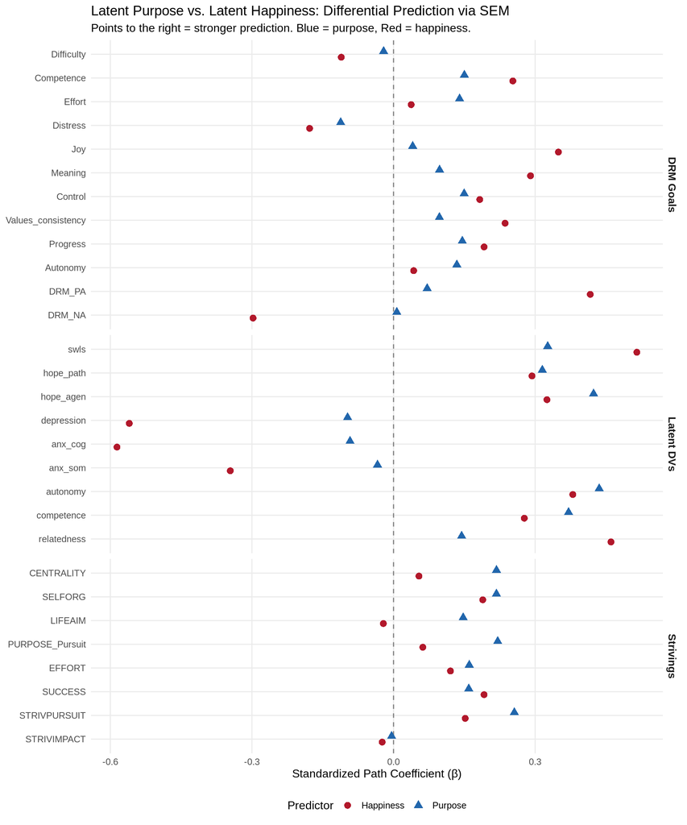

Figure 1: Forest Plot: Standardized SEM Paths from Latent Purpose and Latent Happiness to All Outcomes

Part 3: Exploratory Models

3.1 Network Analysis

Network analysis treats each variable as a node and estimates partial correlations (edges) between all pairs. This reveals the *structure of associations* without imposing directionality or factor structure.

**Show R code**

```
# Network analysis needs qgraph + bootnet. bootnet <= 1.6 imports dplyr::id
# (removed in dplyr 1.0) and fails to load on recent dplyr; bootnet >= 1.8 fixes
# this. If the network section is missing from the output, run
# install.packages("bootnet") to get >= 1.8. We keep the requireNamespace guard
# so an old bootnet skips this section gracefully instead of erroring the whole
# render, and we never call install.packages() during a render.
network_available <- requireNamespace("qgraph", quietly = TRUE) &&
                     requireNamespace("bootnet", quietly = TRUE)

if (network_available) {
  library(qgraph)
  library(bootnet)

  # Select key variables for the network
  network_vars <- c(
    # IVs
    "purpose" = "b_bpurp_mean_POMP",
    "happiness" = "b_shs_mean_POMP",
    # Well-being outcomes
    "life_sat" = "b_swls_mean_POMP",
    "hope" = "b_gshs_mean",
    "depression" = "b_phq_mean_POMP",
    "anxiety" = "b_icsa_mean_POMP",
    "autonomy" = "b_bmpns_AS_mean",
    "competence" = "b_bmpns_CS_mean",
    "relatedness" = "b_bmpns_RS_mean"
  )

  # Add striving vars if available
  striving_network_vars <- c(
    "effort" = "EFFORT_tot_POMP",
    "success" = "SUCCESS_tot_POMP",
    "centrality" = "CENTRALITY_tot_POMP",
    "harmony" = "TOT_STRIVIMPACT_POMP"
  )

  all_network_vars <- c(network_vars, striving_network_vars)
  available_vars <- all_network_vars[all_network_vars %in% names(dat)]

  net_data <- dat[, available_vars]
```

[output cut: 41 more lines]

```
  cat("Node strength (standardized, higher = more connected):\n")
  print(cent_strength[, c("node", "value")], row.names = FALSE)

  # Which node is most central?
  cat("\nMost central node:", cent_strength$node[1], "\n")
  cat("Is purpose or happiness more central?\n")
  purpose_strength <- cent_strength$value[cent_strength$node == "purpose"]
  happiness_strength <- cent_strength$value[cent_strength$node == "happiness"]
  cat("  Purpose strength:", round(purpose_strength, 3), "\n")
  cat("  Happiness strength:", round(happiness_strength, 3), "\n")
} else {
  cat("Network analysis skipped: qgraph/bootnet could not be loaded.\n")
  cat(sprintf("(bootnet imports dplyr::id, removed in dplyr >= 1.0; installed dplyr = %s.)\n",
              as.character(packageVersion("dplyr"))))
}
```

```
── Network Centrality ──
Node strength (standardized, higher = more connected):
        node      value
    life_sat  1.7015909
  competence  0.6052708
   happiness  0.4870340
     success  0.4338852
  depression  0.3469311
      effort  0.2427903
    autonomy  0.2092213
     anxiety  0.1982264
        hope  0.1382777
     purpose -0.4637699
  centrality -0.5034100
 relatedness -0.7503410
     harmony -2.6457069

Most central node: life_sat
Is purpose or happiness more central?
  Purpose strength: -0.464
  Happiness strength: 0.487
```

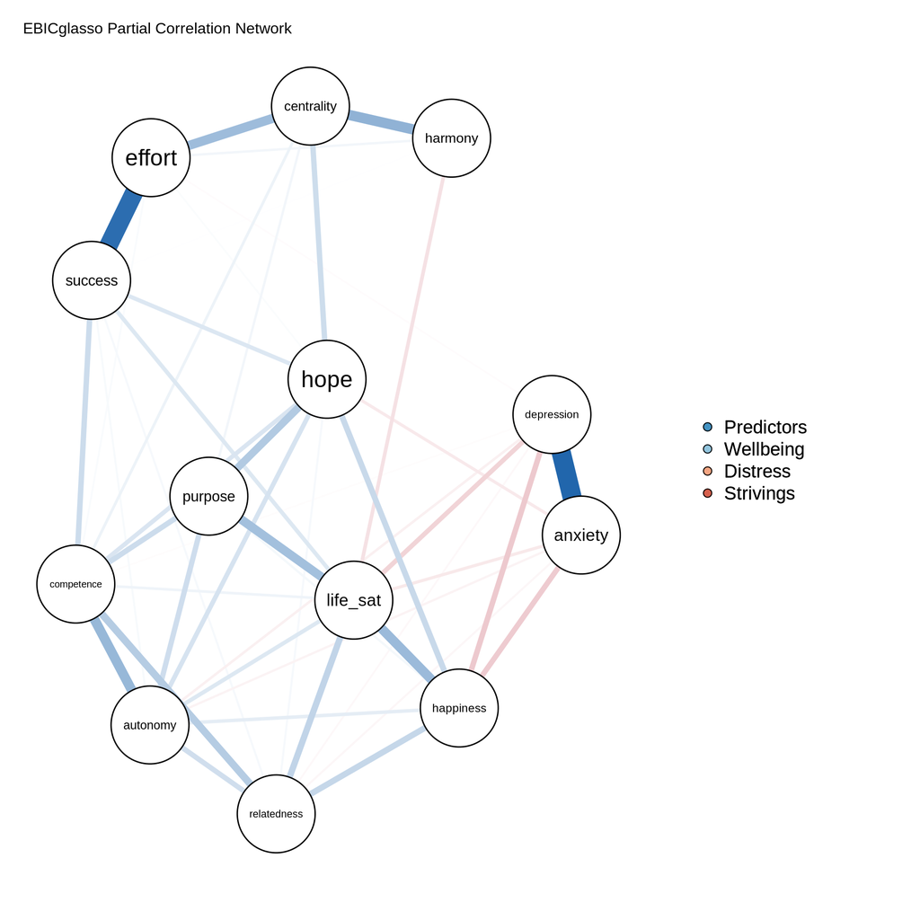

Figure 2: Partial Correlation Network: Purpose, Happiness, and Key Outcomes

3.2 Latent Profile Analysis

Latent Profile Analysis (LPA) identifies subgroups of individuals based on their combinations of purpose and happiness. This answers a different question: are there distinct *types* of people (e.g., “high purpose / low happiness” or “high both”)?

**Show R code**

```
# Check if tidyLPA is available
lpa_available <- requireNamespace("tidyLPA", quietly = TRUE)
if (!lpa_available) {
  cat("tidyLPA not installed. Install with: install.packages('tidyLPA')\n")
}

if (lpa_available) {
  library(tidyLPA)

  # Use purpose and happiness (and maybe PILEA for richer profiles)
  lpa_data <- dat %>%
    dplyr::select(b_bpurp_mean_POMP, b_shs_mean_POMP) %>%
    drop_na()

  cat("LPA sample size:", nrow(lpa_data), "\n")

  # Fit models with 2-5 profiles
  lpa_results <- tryCatch({
    lpa_data %>%
      estimate_profiles(2:5, variances = "equal", covariances = "zero")
  }, error = function(e) {
    cat("LPA model fitting error:", e$message, "\n")
    NULL
  })

  if (!is.null(lpa_results)) {
    # Model comparison
    cat("\n── LPA Model Comparison ──\n")
    comp <- tryCatch(
      get_fit(lpa_results),
      error = function(e) { cat("Fit extraction error:", e$message, "\n"); NULL }
    )

    if (!is.null(comp)) {
      print(comp[, c("Classes", "AIC", "BIC", "Entropy", "n_min", "BLRT_p")])
    }

    # Use best model (lowest BIC) for profiling
    if (!is.null(comp)) {
      best_k <- comp$Classes[which.min(comp$BIC)]
```

[output cut: 27 more lines]

```
          stat_ellipse(level = 0.68, linewidth = 1) +
          scale_color_brewer(palette = "Set1", name = "Profile") +
          labs(
            x = "Purpose (POMP)",
            y = "Happiness (POMP)",
            title = paste0("Latent Profiles (k = ", best_k, ")"),
            subtitle = "Ellipses show 1 SD coverage"
          ) +
          theme_minimal(base_size = 12)
      }
    }
  }
} else {
  cat("tidyLPA not available. Skipping latent profile analysis.\n")
}
```

```
LPA sample size: 314

── LPA Model Comparison ──
# A tibble: 4 × 6
  Classes   AIC   BIC Entropy n_min  BLRT_p
    <int> <dbl> <dbl>   <dbl> <dbl>   <dbl>
1       2 5620. 5647.   0.720 0.322 0.00990
2       3 5606. 5643.   0.728 0.118 0.00990
3       4 5599. 5648.   0.671 0.118 0.00990
4       5 5603. 5663.   0.542 0.118 0.347

Best model (lowest BIC): 3 profiles

── Profile Means ──
```

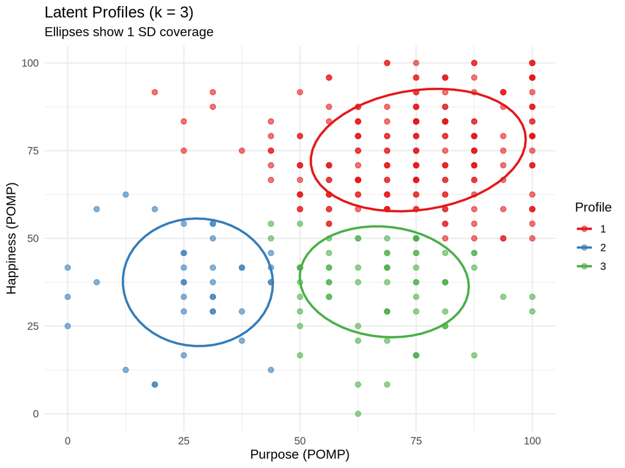

3.3 Exploratory: Personality as Moderator

Does the purpose-happiness distinction depend on personality? We test whether Big Five traits moderate the differential prediction.

**Show R code**

```
# BFI factor scores
# Extraversion: items 1R, 6, 11, 16, 21R, 26R
# Neuroticism: items 4, 9, 14R, 19R, 24R, 29
# Conscientiousness: items 3R, 8R, 13, 18, 23, 28R
# Agreeableness: items 2, 7R, 12, 17R, 22, 27R
# Openness: items 5, 10R, 15, 20R, 25, 30R

bfi_vars <- c(
  # Use _R versions for reverse-scored items
  "B_BFI_1_R", "B_BFI_6", "B_BFI_11", "B_BFI_16", "B_BFI_21_R", "B_BFI_26_R",  # E
  "B_BFI_4", "B_BFI_9", "B_BFI_14_R", "B_BFI_19_R", "B_BFI_24_R", "B_BFI_29",  # N
  "B_BFI_3_R", "B_BFI_8_R", "B_BFI_13", "B_BFI_18", "B_BFI_23", "B_BFI_28_R",  # C
  "B_BFI_2", "B_BFI_7_R", "B_BFI_12", "B_BFI_17_R", "B_BFI_22", "B_BFI_27_R",  # A
  "B_BFI_5", "B_BFI_10_R", "B_BFI_15", "B_BFI_20_R", "B_BFI_25", "B_BFI_30_R"  # O
)

bfi_available <- bfi_vars[bfi_vars %in% names(dat)]
cat("BFI items available:", length(bfi_available), "of", length(bfi_vars), "\n")
```

```
BFI items available: 30 of 30
```

**Show R code**

```
if (length(bfi_available) >= 25) {
  # Compute Big Five composites
  E_items <- c("B_BFI_1_R", "B_BFI_6", "B_BFI_11", "B_BFI_16", "B_BFI_21_R", "B_BFI_26_R")
  N_items <- c("B_BFI_4", "B_BFI_9", "B_BFI_14_R", "B_BFI_19_R", "B_BFI_24_R", "B_BFI_29")
  C_items <- c("B_BFI_3_R", "B_BFI_8_R", "B_BFI_13", "B_BFI_18", "B_BFI_23", "B_BFI_28_R")
  A_items <- c("B_BFI_2", "B_BFI_7_R", "B_BFI_12", "B_BFI_17_R", "B_BFI_22", "B_BFI_27_R")
  O_items <- c("B_BFI_5", "B_BFI_10_R", "B_BFI_15", "B_BFI_20_R", "B_BFI_25", "B_BFI_30_R")

  dat$BFI_E <- rowMeans(dat[, E_items[E_items %in% names(dat)]], na.rm = TRUE)
  dat$BFI_N <- rowMeans(dat[, N_items[N_items %in% names(dat)]], na.rm = TRUE)
  dat$BFI_C <- rowMeans(dat[, C_items[C_items %in% names(dat)]], na.rm = TRUE)
  dat$BFI_A <- rowMeans(dat[, A_items[A_items %in% names(dat)]], na.rm = TRUE)
  dat$BFI_O <- rowMeans(dat[, O_items[O_items %in% names(dat)]], na.rm = TRUE)

  # Center predictors for interaction models
  dat$purpose_c <- scale(dat$b_bpurp_mean_POMP, scale = FALSE)[,1]
  dat$happiness_c <- scale(dat$b_shs_mean_POMP, scale = FALSE)[,1]

  # Test: Does conscientiousness moderate differential prediction?
  # If purpose's effect strengthens at high C (goal-directed people benefit more from purpose),
  # that supports the construct's specificity to striving-related processes.
  dat$BFI_C_c <- scale(dat$BFI_C, scale = FALSE)[,1]

  mod_results <- list()
  dv_list <- c("b_swls_mean_POMP", "EFFORT_tot_POMP", "SUCCESS_tot_POMP")
  dv_labels <- c("Life Satisfaction", "Striving Effort", "Striving Success")

  for (i in seq_along(dv_list)) {
    if (dv_list[i] %in% names(dat)) {
      mod <- lm(reformulate(c("purpose_c", "happiness_c", "BFI_C_c",
                               "purpose_c:BFI_C_c", "happiness_c:BFI_C_c"),
                            response = dv_list[i]),
                data = dat)
      mod_results[[dv_labels[i]]] <- broom::tidy(mod) %>%
        filter(grepl(":", term)) %>%
        mutate(DV = dv_labels[i])
    }
  }

  if (length(mod_results) > 0) {
    mod_table <- bind_rows(mod_results)
    cat("\n── Conscientiousness as Moderator of Differential Prediction ──\n")
    kable(mod_table, digits = 3,
          caption = "Interaction terms: Does conscientiousness moderate purpose vs happiness effects?") %>%
      kable_styling(bootstrap_options = c("striped", "hover"), full_width = FALSE)
  }
} else {
  cat("Insufficient BFI items. Skipping moderation analysis.\n")
}
```

```
── Conscientiousness as Moderator of Differential Prediction ──
```

Interaction terms: Does conscientiousness moderate purpose vs happiness effects?

| term | estimate | std.error | statistic | p.value | DV |
| --- | --- | --- | --- | --- | --- |
| purpose_c:BFI_C_c | 0.068 | 0.063 | 1.073 | 0.284 | Life Satisfaction |
| happiness_c:BFI_C_c | -0.026 | 0.061 | -0.435 | 0.664 | Life Satisfaction |
| purpose_c:BFI_C_c | 0.030 | 0.048 | 0.636 | 0.525 | Striving Effort |
| happiness_c:BFI_C_c | 0.012 | 0.046 | 0.254 | 0.800 | Striving Effort |
| purpose_c:BFI_C_c | 0.009 | 0.049 | 0.190 | 0.849 | Striving Success |
| happiness_c:BFI_C_c | 0.023 | 0.047 | 0.484 | 0.629 | Striving Success |

Part 4: Longitudinal Latent Growth Models

**Show R code**

```
# We have SHS and BPURP at 3 timepoints — perfect for latent growth curves
# Can purpose at T1 predict growth/decline in life satisfaction, hope, depression?

# ── Latent Growth: SWLS over 3 waves ──
# Check what fu-variables exist
fu_swls <- c("b_swls_mean_POMP", "fu1_swls_mean_POMP", "fu2_swls_mean_POMP")
fu_swls_available <- fu_swls[fu_swls %in% names(dat)]
cat("SWLS longitudinal variables:", paste(fu_swls_available, collapse = ", "), "\n")
```

```
SWLS longitudinal variables: b_swls_mean_POMP, fu1_swls_mean_POMP
```

**Show R code**

```
if (length(fu_swls_available) == 3) {
  lgm_swls_model <- '
    # Latent growth factors
    intercept =~ 1*b_swls_mean_POMP + 1*fu1_swls_mean_POMP + 1*fu2_swls_mean_POMP
    slope     =~ 0*b_swls_mean_POMP + 1*fu1_swls_mean_POMP + 2*fu2_swls_mean_POMP

    # Predictors
    intercept ~ purpose_b + happiness_b
    slope     ~ b_p*purpose_b + b_h*happiness_b

    # Define diff
    diff := b_p - b_h
  '

  # Add predictor variables
  dat$purpose_b <- dat$b_bpurp_mean_POMP
  dat$happiness_b <- dat$b_shs_mean_POMP

  lgm_swls_fit <- tryCatch(
    growth(lgm_swls_model, data = dat, missing = "fiml", estimator = "MLR"),
    error = function(e) { cat("LGM SWLS error:", e$message, "\n"); NULL }
  )

  if (!is.null(lgm_swls_fit)) {
    cat("\n── Latent Growth Model: Life Satisfaction ──\n")
    summary(lgm_swls_fit, fit.measures = TRUE, standardized = TRUE)

    params <- parameterEstimates(lgm_swls_fit, standardized = TRUE)
    slope_preds <- params[params$lhs == "slope" & params$op == "~", ]
    cat("\nSlope predictors (does purpose predict CHANGE in life satisfaction?):\n")
    print(slope_preds[, c("rhs", "est", "std.all", "pvalue")])
  }
}

# ── Latent Growth: Depression (PHQ) over 3 waves ──
fu_phq <- c("b_phq_mean_POMP", "fu1_phq_mean_POMP", "fu2_phq_mean_POMP")
fu_phq_available <- fu_phq[fu_phq %in% names(dat)]
cat("\nPHQ longitudinal variables:", paste(fu_phq_available, collapse = ", "), "\n")
```

```
PHQ longitudinal variables: b_phq_mean_POMP, fu1_phq_mean_POMP
```

**Show R code**

```
if (length(fu_phq_available) == 3) {
  lgm_phq_model <- '
    intercept =~ 1*b_phq_mean_POMP + 1*fu1_phq_mean_POMP + 1*fu2_phq_mean_POMP
    slope     =~ 0*b_phq_mean_POMP + 1*fu1_phq_mean_POMP + 2*fu2_phq_mean_POMP

    intercept ~ purpose_b + happiness_b
    slope     ~ b_p*purpose_b + b_h*happiness_b

    diff := b_p - b_h
  '

  lgm_phq_fit <- tryCatch(
    growth(lgm_phq_model, data = dat, missing = "fiml", estimator = "MLR"),
    error = function(e) { cat("LGM PHQ error:", e$message, "\n"); NULL }
  )

  if (!is.null(lgm_phq_fit)) {
    cat("\n── Latent Growth Model: Depression ──\n")
    summary(lgm_phq_fit, fit.measures = TRUE, standardized = TRUE)

    params <- parameterEstimates(lgm_phq_fit, standardized = TRUE)
    slope_preds <- params[params$lhs == "slope" & params$op == "~", ]
    cat("\nSlope predictors (does purpose predict CHANGE in depression?):\n")
    print(slope_preds[, c("rhs", "est", "std.all", "pvalue")])
  }
}

# ── Latent Growth: Hope (GSHS) over 3 waves ──
fu_gshs <- c("b_gshs_mean", "fu1_gshs_mean", "fu2_gshs_mean")
fu_gshs_available <- fu_gshs[fu_gshs %in% names(dat)]

if (length(fu_gshs_available) == 3) {
  lgm_gshs_model <- '
    intercept =~ 1*b_gshs_mean + 1*fu1_gshs_mean + 1*fu2_gshs_mean
    slope     =~ 0*b_gshs_mean + 1*fu1_gshs_mean + 2*fu2_gshs_mean

    intercept ~ purpose_b + happiness_b
    slope     ~ b_p*purpose_b + b_h*happiness_b

    diff := b_p - b_h
  '

  lgm_gshs_fit <- tryCatch(
    growth(lgm_gshs_model, data = dat, missing = "fiml", estimator = "MLR"),
    error = function(e) { cat("LGM GSHS error:", e$message, "\n"); NULL }
  )

  if (!is.null(lgm_gshs_fit)) {
    cat("\n── Latent Growth Model: Hope ──\n")
    summary(lgm_gshs_fit, fit.measures = TRUE, standardized = TRUE)

    params <- parameterEstimates(lgm_gshs_fit, standardized = TRUE)
    slope_preds <- params[params$lhs == "slope" & params$op == "~", ]
    cat("\nSlope predictors:\n")
    print(slope_preds[, c("rhs", "est", "std.all", "pvalue")])
  }
}
```

```
LGM GSHS error: lavaan->lav_data_full():
   some (observed) variables specified in the model are not found in the
   dataset: purpose_b happiness_b
```

Part 5: Grand Summary

**Show R code**

```
cat("══════════════════════════════════════════════════════════════════\n")
```

```
══════════════════════════════════════════════════════════════════
```

**Show R code**

```
cat("  WILDCHILD GRAND SUMMARY\n")
```

```
  WILDCHILD GRAND SUMMARY
```

**Show R code**

```
cat("══════════════════════════════════════════════════════════════════\n\n")
```

```
══════════════════════════════════════════════════════════════════
```

**Show R code**

```
cat("MEASUREMENT MODELS:\n")
```

```
MEASUREMENT MODELS:
```

**Show R code**

```
cat("─────────────────\n")
```

**Show R code**

```
if (exists("fit_summary")) {
  cat("All measurement models fitted. See Part 1 for fit indices.\n")
  cat("Key question: Are purpose and happiness distinct latent constructs?\n")
  if (exists("latent_cor")) {
    cat(sprintf("  Latent correlation (purpose ↔ happiness) = %.3f\n", latent_cor[1,2]))
    cat(sprintf("  Observed correlation = %.3f\n",
                cor(dat$b_bpurp_mean_POMP, dat$b_shs_mean_POMP, use = "complete.obs")))
    cat("  → Latent r > observed r (corrected for measurement error)\n")
    cat(sprintf("  → But latent r = %.2f is still well below 1.0 → distinct constructs\n", latent_cor[1,2]))
  }
}
```

```
All measurement models fitted. See Part 1 for fit indices.
Key question: Are purpose and happiness distinct latent constructs?
  Latent correlation (purpose ↔ happiness) = 0.439
  Observed correlation = 0.396
  → Latent r > observed r (corrected for measurement error)
  → But latent r = 0.44 is still well below 1.0 → distinct constructs
```

**Show R code**

```
cat("\nSTRUCTURAL MODELS:\n")
```

```
STRUCTURAL MODELS:
```

**Show R code**

```
cat("─────────────────\n")
```

**Show R code**

```
cat("(Counts use valence-corrected betas; negative outcomes sign-flipped so\n")
```

```
(Counts use valence-corrected betas; negative outcomes sign-flipped so
```

**Show R code**

```
cat(" higher = better. Read per-outcome, not as a verdict — see Part 2.)\n")
```

```
 higher = better. Read per-outcome, not as a verdict — see Part 2.)
```

**Show R code**

```
if (exists("sem_table") && nrow(sem_table) > 0 && "Valenced diff (P-H)" %in% names(sem_table)) {
  cat(sprintf("Latent DVs: Purpose the stronger beneficial path in %d of %d outcomes\n",
              sum(sem_table$`Valenced diff (P-H)` > 0, na.rm = TRUE), nrow(sem_table)))
  cat(sprintf("  Significant path differences: %d of %d (FDR < .05)\n",
              sum(sem_table$`p (FDR)` < .05, na.rm = TRUE), nrow(sem_table)))
  cat(sprintf("  Average valenced β: Purpose = %.3f, Happiness = %.3f\n",
              mean(sem_table$`βv Purpose`, na.rm = TRUE),
              mean(sem_table$`βv Happiness`, na.rm = TRUE)))
}
```

```
Latent DVs: Purpose the stronger beneficial path in 4 of 9 outcomes
  Significant path differences: 2 of 9 (FDR < .05)
  Average valenced β: Purpose = 0.249, Happiness = 0.416
```

**Show R code**

```
if (exists("obs_sem_table") && nrow(obs_sem_table) > 0 && "Valenced diff (P-H)" %in% names(obs_sem_table)) {
  cat(sprintf("\nObserved DVs: Purpose the stronger beneficial path in %d of %d outcomes\n",
              sum(obs_sem_table$`Valenced diff (P-H)` > 0, na.rm = TRUE), nrow(obs_sem_table)))
  cat(sprintf("  Significant path differences: %d of %d (FDR < .05)\n",
              sum(obs_sem_table$`p (FDR)` < .05, na.rm = TRUE), nrow(obs_sem_table)))
}
```

```
Observed DVs: Purpose the stronger beneficial path in 9 of 20 outcomes
  Significant path differences: 0 of 20 (FDR < .05)
```

**Show R code**

```
cat("\nEXPLORATORY FINDINGS:\n")
```

```
EXPLORATORY FINDINGS:
```

**Show R code**

```
cat("─────────────────────\n")
```

**Show R code**

```
if (exists("purpose_strength") && exists("happiness_strength")) {
  cat(sprintf("Network centrality: Purpose = %.3f, Happiness = %.3f\n",
              purpose_strength, happiness_strength))
  if (purpose_strength > happiness_strength) {
    cat("  → Purpose is more central in the psychological network\n")
  } else {
    cat("  → Happiness is more central in the psychological network\n")
  }
}
```

```
Network centrality: Purpose = -0.464, Happiness = 0.487
  → Happiness is more central in the psychological network
```

**Show R code**

```
cat("\nLONGITUDINAL GROWTH:\n")
```

```
LONGITUDINAL GROWTH:
```

**Show R code**

```
cat("────────────────────\n")
```

**Show R code**

[output not shown]

[output not shown]

**Show R code**

```
cat("Key question: Does baseline purpose predict CHANGE (slope) beyond happiness?\n")
```

```
Key question: Does baseline purpose predict CHANGE (slope) beyond happiness?
```

**Show R code**

```
cat("\n══════════════════════════════════════════════════════════════════\n")
```

```
══════════════════════════════════════════════════════════════════
```

**Show R code**

```
cat("  END OF WILDCHILD ANALYSIS\n")
```

```
  END OF WILDCHILD ANALYSIS
```

**Show R code**

```
cat("══════════════════════════════════════════════════════════════════\n")
```

```
══════════════════════════════════════════════════════════════════
```

Discussion Notes (For Co-Author Review)

What This Version Adds Beyond the Original

1. **Measurement model validation**: Formal CFA evidence that purpose and happiness are distinct at the latent level (not just different observed scores)

2. **Disattenuated structural effects**: SEM paths correct for measurement error — if effects get stronger, that means measurement error was masking true relationships

4. **Network perspective**: Shows the *system* of relationships without forcing a predictor → outcome framework

5. **Latent profiles**: Identifies whether there are meaningful subgroups defined by purpose-happiness combinations

Contribution Opportunity for Todd & PEM

- **Latent class of coping users**: LPA on the 14 coping strategies to identify regulatory profiles (flexible, rigid-positive, rigid-avoidant)

- **Entropy-based flexibility index**: Shannon entropy across strategy use

- **CFA-derived flexibility**: If we can identify items that measure the *process* of switching strategies

This is a genuine design choice that shapes the story. Which approach best captures what you mean by “regulatory flexibility”?

What’s Risky in This Version

1. **Bifactor models are known to overfit** — they can absorb residual correlations without representing real constructs

2. **Network analysis is cross-sectional** — edges don’t imply causation

3. **LPA is exploratory** — profile solutions depend heavily on sample characteristics and may not replicate

4. **Small item sets** (4 items for SHS and BPURP) may limit latent variable identification

5. **FIML assumes MAR** — same as MICE in the original, but implemented differently

References